# SR_03_RLTD_ORG_PTR_ADDR_L1

Related organization street address line 1 · Text report

## Overview

**Description**

Address Foreign - AddressLine1

**Table**

`SR-P03-T01-ID-RLTD-ORGS-TAXABLE-PARTNERSHIP` (many)

**Location code**

`SCHED-R-PART-03-COL-A`

**Family**

`SCHED-R-PART-03-COL-A` · siblings: SR_03_RLTD_ORG_PTR_ADDR_CITY, SR_03_RLTD_ORG_PTR_ADDR_CNTR, SR_03_RLTD_ORG_PTR_ADDR_L2, SR_03_RLTD_ORG_PTR_ADDR_STATE, SR_03_RLTD_ORG_PTR_ADDR_ZIP, SR_03_RLTD_ORG_PTR_EIN

**Data type**

text (xsd: StreetAddressType)

**Scope**

PC

**Status**

unreviewed

6

xpaths mapped (6 observed)

147,095

filings with a value

2009–2024

tax years observed

1

open flags (1 errors)

## Flags

| Severity | Flag | Xpath | Detail |
| --- | --- | --- | --- |
| ⚠ error | `COLLISION` | IRS990ScheduleR/IdRelatedOrgTxblPartnershipGrp/ForeignAddress/AddressLine1Txt | 2349 filings contain 2+ of its xpaths; most common set: /Return/ReturnData/IRS990ScheduleR/IdRelatedOrgTxblPartnershipGrp/ForeignAddress/AddressLine1Txt ; /Return/ReturnData/IRS990ScheduleR/IdRelatedO… |

## Xpaths

All mapped xpaths (under /Return/ReturnData or /Return/ReturnHeader), oldest first. Charts label each series by its xpath.

| Xpath | Form | Chart label | First year | Last year | Versions | Filings | Repeats in |
| --- | --- | --- | --- | --- | --- | --- | --- |
| IRS990ScheduleR/Form990ScheduleRPartIII/AddressUS/AddressLine1 | Sched R | …0ScheduleR/Form990ScheduleRPartIII/AddressUS/AddressLine1 | 2009 | 2012 | 16 | 23,460 | 65.1% |
| IRS990ScheduleR/Form990ScheduleRPartIII/AddressForeign/AddressLine1 | Sched R | …duleR/Form990ScheduleRPartIII/AddressForeign/AddressLine1 | 2009 | 2012 | 13 | 178 | 68.5% |
| IRS990ScheduleR/IdRelatedOrgTxblPartnershipGrp/USAddress/AddressLine1 | Sched R | …leR/IdRelatedOrgTxblPartnershipGrp/USAddress/AddressLine1 | 2013 | 2013 | 3 | 8,258 | 65.2% |
| IRS990ScheduleR/IdRelatedOrgTxblPartnershipGrp/ForeignAddress/AddressLine1 | Sched R | …dRelatedOrgTxblPartnershipGrp/ForeignAddress/AddressLine1 | 2013 | 2013 | 3 | 69 | 52.2% |
| IRS990ScheduleR/IdRelatedOrgTxblPartnershipGrp/USAddress/AddressLine1Txt | Sched R | …/IdRelatedOrgTxblPartnershipGrp/USAddress/AddressLine1Txt | 2014 | 2024 | 34 | 112,705 | 66.8% |
| IRS990ScheduleR/IdRelatedOrgTxblPartnershipGrp/ForeignAddress/AddressLine1Txt | Sched R | …latedOrgTxblPartnershipGrp/ForeignAddress/AddressLine1Txt | 2014 | 2024 | 31 | 2,425 | 49.4% |

## Coverage

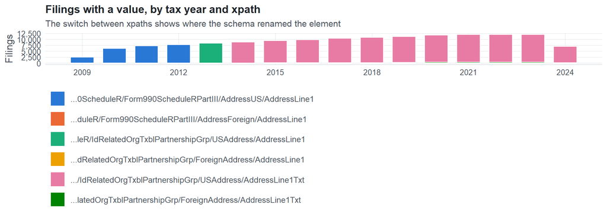

**Table view**

Table view: filings by tax year and series

| Tax year | …0ScheduleR/Form990ScheduleRPartIII/AddressUS/AddressLine1 | …duleR/Form990ScheduleRPartIII/AddressForeign/AddressLine1 | …leR/IdRelatedOrgTxblPartnershipGrp/USAddress/AddressLine1 | …dRelatedOrgTxblPartnershipGrp/ForeignAddress/AddressLine1 | …/IdRelatedOrgTxblPartnershipGrp/USAddress/AddressLine1Txt | …latedOrgTxblPartnershipGrp/ForeignAddress/AddressLine1Txt |
| --- | --- | --- | --- | --- | --- | --- |
| 2009 | 2,408 | 23 | 0 | 0 | 0 | 0 |
| 2010 | 6,092 | 52 | 0 | 0 | 0 | 0 |
| 2011 | 7,239 | 47 | 0 | 0 | 0 | 0 |
| 2012 | 7,721 | 56 | 0 | 0 | 0 | 0 |
| 2013 | 0 | 0 | 8,258 | 69 | 0 | 0 |
| 2014 | 0 | 0 | 0 | 0 | 8,789 | 69 |
| 2015 | 0 | 0 | 0 | 0 | 9,294 | 123 |
| 2016 | 0 | 0 | 0 | 0 | 9,719 | 130 |
| 2017 | 0 | 0 | 0 | 0 | 10,305 | 116 |
| 2018 | 0 | 0 | 0 | 0 | 10,609 | 133 |
| 2019 | 0 | 0 | 0 | 0 | 10,877 | 294 |
| 2020 | 0 | 0 | 0 | 0 | 11,397 | 351 |
| 2021 | 0 | 0 | 0 | 0 | 11,570 | 362 |
| 2022 | 0 | 0 | 0 | 0 | 11,667 | 360 |
| 2023 | 0 | 0 | 0 | 0 | 11,569 | 392 |
| 2024 | 0 | 0 | 0 | 0 | 6,909 | 95 |

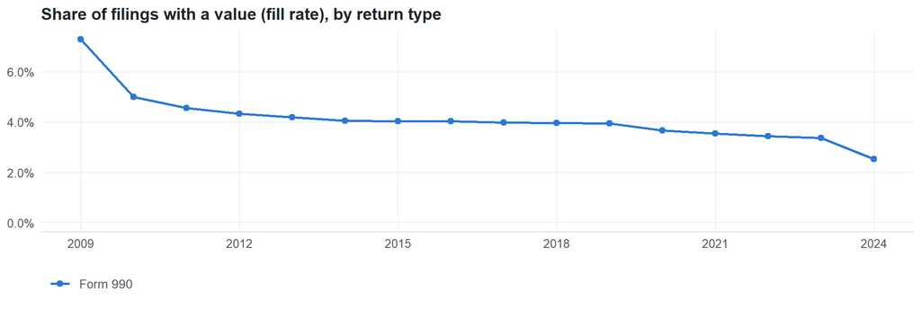

**Table view**

Table view: fill rate

| Tax year | Return type | Filings | All filings | Fill rate |
| --- | --- | --- | --- | --- |
| 2009 | Form 990 | 2,431 | 33,311 | 7.30% |
| 2010 | Form 990 | 6,144 | 123,025 | 4.99% |
| 2011 | Form 990 | 7,286 | 159,504 | 4.57% |
| 2012 | Form 990 | 7,777 | 179,688 | 4.33% |
| 2013 | Form 990 | 8,327 | 198,855 | 4.19% |
| 2014 | Form 990 | 8,858 | 218,619 | 4.05% |
| 2015 | Form 990 | 9,417 | 233,519 | 4.03% |
| 2016 | Form 990 | 9,849 | 243,903 | 4.04% |
| 2017 | Form 990 | 10,421 | 261,612 | 3.98% |
| 2018 | Form 990 | 10,742 | 271,442 | 3.96% |
| 2019 | Form 990 | 11,171 | 283,694 | 3.94% |
| 2020 | Form 990 | 11,748 | 320,342 | 3.67% |
| 2021 | Form 990 | 11,932 | 336,480 | 3.55% |
| 2022 | Form 990 | 12,027 | 349,055 | 3.45% |
| 2023 | Form 990 | 11,961 | 354,768 | 3.37% |
| 2024 | Form 990 | 7,004 | 277,298 | 2.53% |

## Repeating groups

Table cardinality in the concordance: **many**. 6 of 6 observed xpaths repeat within a filing.

Repeating element each xpath was observed in (from the raw indexed xpath)

| Xpath | Repeating element | Filings (summed over years) |
| --- | --- | --- |
| IRS990ScheduleR/Form990ScheduleRPartIII/AddressForeign/AddressLine1 | (none) | 30 |
| IRS990ScheduleR/Form990ScheduleRPartIII/AddressForeign/AddressLine1 | IRS990ScheduleR/Form990ScheduleRPartIII | 148 |
| IRS990ScheduleR/Form990ScheduleRPartIII/AddressUS/AddressLine1 | (none) | 8148 |
| IRS990ScheduleR/Form990ScheduleRPartIII/AddressUS/AddressLine1 | IRS990ScheduleR/Form990ScheduleRPartIII | 15312 |
| IRS990ScheduleR/IdRelatedOrgTxblPartnershipGrp/ForeignAddress/AddressLine1 | (none) | 19 |
| IRS990ScheduleR/IdRelatedOrgTxblPartnershipGrp/ForeignAddress/AddressLine1 | IRS990ScheduleR/IdRelatedOrgTxblPartnershipGrp | 50 |
| IRS990ScheduleR/IdRelatedOrgTxblPartnershipGrp/USAddress/AddressLine1 | (none) | 2857 |
| IRS990ScheduleR/IdRelatedOrgTxblPartnershipGrp/USAddress/AddressLine1 | IRS990ScheduleR/IdRelatedOrgTxblPartnershipGrp | 5401 |
| IRS990ScheduleR/IdRelatedOrgTxblPartnershipGrp/ForeignAddress/AddressLine1Txt | (none) | 243 |
| IRS990ScheduleR/IdRelatedOrgTxblPartnershipGrp/ForeignAddress/AddressLine1Txt | IRS990ScheduleR/IdRelatedOrgTxblPartnershipGrp | 2182 |
| IRS990ScheduleR/IdRelatedOrgTxblPartnershipGrp/USAddress/AddressLine1Txt | (none) | 37222 |
| IRS990ScheduleR/IdRelatedOrgTxblPartnershipGrp/USAddress/AddressLine1Txt | IRS990ScheduleR/IdRelatedOrgTxblPartnershipGrp | 75483 |

## Values

| Result | Check | Detail |
| --- | --- | --- |
| ✓ pass | Values are text, not numbers | 0% of values are numeric |
| ⓘ info | No sign of truncation | …0ScheduleR/Form990ScheduleRPartIII/AddressUS/AddressLine1: longest value is exactly 35 characters; …latedOrgTxblPartnershipGrp/ForeignAddress/AddressLine1Txt: longest value is exactly 35 characters; … |
| ⓘ info | No dominant boilerplate value | most common value covers 32% of filings: “709 WING ON PLAZA 62 MODY ROAD TS” |

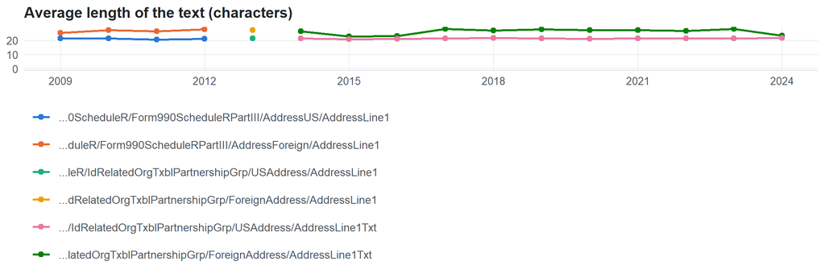

**Table view**

Table view: length and variety by tax year

| Series | Tax year | Filings | Avg length | Max length | Distinct values (approx.) |
| --- | --- | --- | --- | --- | --- |
| …0ScheduleR/Form990ScheduleRPartIII/AddressUS/AddressLine1 | 2009 | 2,408 | 21 | 35 | 2,376 |
| …0ScheduleR/Form990ScheduleRPartIII/AddressUS/AddressLine1 | 2010 | 6,092 | 21 | 35 | 3,103 |
| …0ScheduleR/Form990ScheduleRPartIII/AddressUS/AddressLine1 | 2011 | 7,239 | 20 | 35 | 3,936 |
| …0ScheduleR/Form990ScheduleRPartIII/AddressUS/AddressLine1 | 2012 | 7,721 | 21 | 35 | 5,459 |
| …duleR/Form990ScheduleRPartIII/AddressForeign/AddressLine1 | 2009 | 23 | 25 | 34 | 26 |
| …duleR/Form990ScheduleRPartIII/AddressForeign/AddressLine1 | 2010 | 52 | 27 | 34 | 47 |
| …duleR/Form990ScheduleRPartIII/AddressForeign/AddressLine1 | 2011 | 47 | 26 | 34 | 57 |
| …duleR/Form990ScheduleRPartIII/AddressForeign/AddressLine1 | 2012 | 56 | 28 | 34 | 34 |
| …leR/IdRelatedOrgTxblPartnershipGrp/USAddress/AddressLine1 | 2013 | 8,258 | 21 | 35 | 3,983 |
| …dRelatedOrgTxblPartnershipGrp/ForeignAddress/AddressLine1 | 2013 | 69 | 27 | 34 | 75 |
| …/IdRelatedOrgTxblPartnershipGrp/USAddress/AddressLine1Txt | 2014 | 8,789 | 21 | 35 | 3,677 |
| …/IdRelatedOrgTxblPartnershipGrp/USAddress/AddressLine1Txt | 2015 | 9,294 | 21 | 35 | 4,073 |
| …/IdRelatedOrgTxblPartnershipGrp/USAddress/AddressLine1Txt | 2016 | 9,719 | 21 | 35 | 6,959 |
| …/IdRelatedOrgTxblPartnershipGrp/USAddress/AddressLine1Txt | 2017 | 10,305 | 21 | 35 | 5,384 |
| …/IdRelatedOrgTxblPartnershipGrp/USAddress/AddressLine1Txt | 2018 | 10,609 | 22 | 35 | 6,737 |
| …/IdRelatedOrgTxblPartnershipGrp/USAddress/AddressLine1Txt | 2019 | 10,877 | 21 | 35 | 5,479 |
| …/IdRelatedOrgTxblPartnershipGrp/USAddress/AddressLine1Txt | 2020 | 11,397 | 21 | 35 | 6,006 |
| …/IdRelatedOrgTxblPartnershipGrp/USAddress/AddressLine1Txt | 2021 | 11,570 | 21 | 35 | 9,728 |
| …/IdRelatedOrgTxblPartnershipGrp/USAddress/AddressLine1Txt | 2022 | 11,667 | 21 | 35 | 11,504 |
| …/IdRelatedOrgTxblPartnershipGrp/USAddress/AddressLine1Txt | 2023 | 11,569 | 22 | 35 | 6,149 |
| …/IdRelatedOrgTxblPartnershipGrp/USAddress/AddressLine1Txt | 2024 | 6,909 | 22 | 35 | 4,896 |
| …latedOrgTxblPartnershipGrp/ForeignAddress/AddressLine1Txt | 2014 | 69 | 26 | 35 | 73 |
| …latedOrgTxblPartnershipGrp/ForeignAddress/AddressLine1Txt | 2015 | 123 | 23 | 35 | 66 |
| …latedOrgTxblPartnershipGrp/ForeignAddress/AddressLine1Txt | 2016 | 130 | 23 | 35 | 61 |
| …latedOrgTxblPartnershipGrp/ForeignAddress/AddressLine1Txt | 2017 | 116 | 28 | 35 | 66 |
| …latedOrgTxblPartnershipGrp/ForeignAddress/AddressLine1Txt | 2018 | 133 | 27 | 35 | 76 |
| …latedOrgTxblPartnershipGrp/ForeignAddress/AddressLine1Txt | 2019 | 294 | 28 | 35 | 66 |
| …latedOrgTxblPartnershipGrp/ForeignAddress/AddressLine1Txt | 2020 | 351 | 27 | 35 | 58 |
| …latedOrgTxblPartnershipGrp/ForeignAddress/AddressLine1Txt | 2021 | 362 | 27 | 35 | 152 |
| …latedOrgTxblPartnershipGrp/ForeignAddress/AddressLine1Txt | 2022 | 360 | 27 | 35 | 163 |
| …latedOrgTxblPartnershipGrp/ForeignAddress/AddressLine1Txt | 2023 | 392 | 28 | 35 | 113 |
| …latedOrgTxblPartnershipGrp/ForeignAddress/AddressLine1Txt | 2024 | 95 | 23 | 35 | 69 |

Most common values by xpath (all years; long values truncated)

| Series | Value | Filings | Share |
| --- | --- | --- | --- |
| …0ScheduleR/Form990ScheduleRPartIII/AddressUS/AddressLine1 | 107 S TSCHIRLEY RD | 564 | 2.4% |
| …0ScheduleR/Form990ScheduleRPartIII/AddressUS/AddressLine1 | 111 S TSCHIRLEY RD | 564 | 2.4% |
| …0ScheduleR/Form990ScheduleRPartIII/AddressUS/AddressLine1 | 1200 CROY DR | 564 | 2.4% |
| …0ScheduleR/Form990ScheduleRPartIII/AddressUS/AddressLine1 | 1220 JEFFERSON AVE | 564 | 2.4% |
| …0ScheduleR/Form990ScheduleRPartIII/AddressUS/AddressLine1 | 1330 BLAKELY CIRCLE SW | 564 | 2.4% |
| …0ScheduleR/Form990ScheduleRPartIII/AddressUS/AddressLine1 | 1 BATTLE SQUARE | 375 | 1.6% |
| …0ScheduleR/Form990ScheduleRPartIII/AddressUS/AddressLine1 | 111 N CHAPEL AVE | 375 | 1.6% |
| …0ScheduleR/Form990ScheduleRPartIII/AddressUS/AddressLine1 | 115 FRANKLIN STREET | 375 | 1.6% |
| …0ScheduleR/Form990ScheduleRPartIII/AddressUS/AddressLine1 | 11500 DETROIT AVENUE | 375 | 1.6% |
| …0ScheduleR/Form990ScheduleRPartIII/AddressUS/AddressLine1 | 122 SEVENTH STREET | 375 | 1.6% |
| …0ScheduleR/Form990ScheduleRPartIII/AddressUS/AddressLine1 | 1660 DUKE STREET | 191 | 0.8% |
| …0ScheduleR/Form990ScheduleRPartIII/AddressUS/AddressLine1 | 1 CALLE 5-1 ADM OFFICE | 189 | 0.8% |
| …0ScheduleR/Form990ScheduleRPartIII/AddressUS/AddressLine1 | 108 DEBORAH DR | 189 | 0.8% |
| …0ScheduleR/Form990ScheduleRPartIII/AddressUS/AddressLine1 | 110 STURBRIDGE RD | 189 | 0.8% |
| …0ScheduleR/Form990ScheduleRPartIII/AddressUS/AddressLine1 | 1280 NORTON AVE | 189 | 0.8% |
| …0ScheduleR/Form990ScheduleRPartIII/AddressUS/AddressLine1 | 11650 West 2nd Place | 100 | 0.4% |
| …0ScheduleR/Form990ScheduleRPartIII/AddressUS/AddressLine1 | 1390 Kelly Johnson Blvd | 100 | 0.4% |
| …0ScheduleR/Form990ScheduleRPartIII/AddressUS/AddressLine1 | 1601 NW 114th St Suite 244 | 100 | 0.4% |
| …0ScheduleR/Form990ScheduleRPartIII/AddressUS/AddressLine1 | 2209 Wildwood Avenue | 100 | 0.4% |
| …0ScheduleR/Form990ScheduleRPartIII/AddressUS/AddressLine1 | 3004 W Faidley Ave | 100 | 0.4% |
| …0ScheduleR/Form990ScheduleRPartIII/AddressUS/AddressLine1 | 314 Martin Luther King Jr Way 11 | 100 | 0.4% |
| …0ScheduleR/Form990ScheduleRPartIII/AddressUS/AddressLine1 | 4231 W 16th Avenue | 100 | 0.4% |
| …0ScheduleR/Form990ScheduleRPartIII/AddressUS/AddressLine1 | 5000 North 26th Street | 100 | 0.4% |
| …0ScheduleR/Form990ScheduleRPartIII/AddressUS/AddressLine1 | 5390 N Academy Blvd Suite 300 | 100 | 0.4% |
| …0ScheduleR/Form990ScheduleRPartIII/AddressUS/AddressLine1 | 555 South Park Avenue Plaza 11 | 100 | 0.4% |
| …duleR/Form990ScheduleRPartIII/AddressForeign/AddressLine1 | AV DR CARDOSO DE MELO 1340-11 AN | 43 | 24.2% |
| …duleR/Form990ScheduleRPartIII/AddressForeign/AddressLine1 | PO BOX 1234 GT QUEENSGATE HOUSE S | 35 | 19.7% |
| …duleR/Form990ScheduleRPartIII/AddressForeign/AddressLine1 | 20 RUE DE LA POSTE L-2346 | 32 | 18.0% |
| …duleR/Form990ScheduleRPartIII/AddressForeign/AddressLine1 | AVDA SANTA MARIA NO 6350 PISO 3 | 32 | 18.0% |
| …duleR/Form990ScheduleRPartIII/AddressForeign/AddressLine1 | PO BOX 309GT UGLAND HOUSE S CHURC | 27 | 15.2% |

First rows shown.

## Examples

| Tax year | Return | Xpath | Organization | Value | Source |
| --- | --- | --- | --- | --- | --- |
| 2024 | 990 | IRS990ScheduleR/IdRelatedOrgTxblPartnershipGrp/ForeignAddress/AddressLine1Txt | McMaster University | 175 Longwood Rd S Ste 105 | [XML](https://gt990datalake-rawdata.s3.amazonaws.com/EfileData/XmlFiles/202620709349301752_public.xml) |
| 2024 | 990 | IRS990ScheduleR/IdRelatedOrgTxblPartnershipGrp/USAddress/AddressLine1Txt | RISEWELL COMMUNITY SERVICES INC FKA | 1 FARMINGDALE ROAD- ROUTE 109 | [XML](https://gt990datalake-rawdata.s3.amazonaws.com/EfileData/XmlFiles/202610589349301811_public.xml) |
| 2023 | 990 | IRS990ScheduleR/IdRelatedOrgTxblPartnershipGrp/ForeignAddress/AddressLine1Txt | Harvard Real Estate - Allston Inc | PO BOX 309 UGLAND HOUSE | [XML](https://gt990datalake-rawdata.s3.amazonaws.com/EfileData/XmlFiles/202541359349307959_public.xml) |
| 2023 | 990 | IRS990ScheduleR/IdRelatedOrgTxblPartnershipGrp/USAddress/AddressLine1Txt | Neurology Associates of Stony Brook University Faculty Practice Corp | PO BOX 1554 | [XML](https://gt990datalake-rawdata.s3.amazonaws.com/EfileData/XmlFiles/202531339349306648_public.xml) |
| 2022 | 990 | IRS990ScheduleR/IdRelatedOrgTxblPartnershipGrp/ForeignAddress/AddressLine1Txt | BAYLOR ST LUKE’S MEDICAL GROUP | 709 WING ON PLAZA 62 MODY ROAD TS | [XML](https://gt990datalake-rawdata.s3.amazonaws.com/EfileData/XmlFiles/202431349349303418_public.xml) |
| 2022 | 990 | IRS990ScheduleR/IdRelatedOrgTxblPartnershipGrp/USAddress/AddressLine1Txt | Alexian Brothers - AHS Midwest Region Health Co | 935 Beisner | [XML](https://gt990datalake-rawdata.s3.amazonaws.com/EfileData/XmlFiles/202401369349308605_public.xml) |
| 2021 | 990 | IRS990ScheduleR/IdRelatedOrgTxblPartnershipGrp/ForeignAddress/AddressLine1Txt | DUKE CORPORATE EDUCATION | 50 LOTHIAN ROAD FESTIAL SQUARE | [XML](https://gt990datalake-rawdata.s3.amazonaws.com/EfileData/XmlFiles/202331329349307778_public.xml) |
| 2021 | 990 | IRS990ScheduleR/IdRelatedOrgTxblPartnershipGrp/USAddress/AddressLine1Txt | Methodist-CDI | 11221 ROE AVE | [XML](https://gt990datalake-rawdata.s3.amazonaws.com/EfileData/XmlFiles/202233199349316433_public.xml) |
| 2020 | 990 | IRS990ScheduleR/IdRelatedOrgTxblPartnershipGrp/ForeignAddress/AddressLine1Txt | LAKEWOOD REGIONAL HEALTHCARE FOUNDATION | 709 WING ON PLAZA 62 MODY ROAD TS | [XML](https://gt990datalake-rawdata.s3.amazonaws.com/EfileData/XmlFiles/202201339349303840_public.xml) |
| 2020 | 990 | IRS990ScheduleR/IdRelatedOrgTxblPartnershipGrp/USAddress/AddressLine1Txt | SMYRNA RHF HOUSING INC | 10 TEMPLE PLACE | [XML](https://gt990datalake-rawdata.s3.amazonaws.com/EfileData/XmlFiles/202240179349300204_public.xml) |
| 2019 | 990 | IRS990ScheduleR/IdRelatedOrgTxblPartnershipGrp/ForeignAddress/AddressLine1Txt | CENTENNIAL MEDICAL GROUP INC | 709 WING ON PLAZA 62 MODY ROAD TS | [XML](https://gt990datalake-rawdata.s3.amazonaws.com/EfileData/XmlFiles/202131319349301578_public.xml) |
| 2019 | 990 | IRS990ScheduleR/IdRelatedOrgTxblPartnershipGrp/USAddress/AddressLine1Txt | CEDARS-SINAI MEDICAL CENTER | 12400 WILSHIRE BLVD STE 100 | [XML](https://gt990datalake-rawdata.s3.amazonaws.com/EfileData/XmlFiles/202131349349305998_public.xml) |

## Reviewer checklist

- The definition matches the form line and instructions for every xpath’s schema years.
- Every xpath pooled here measures the same thing on the 990 and 990-EZ (close enough for analysis).
- The coverage chart has no unexplained gaps or jumps between tax years.
- Each open flag is fixed, or accepted with a note in validation_log.csv.
- Values answer the question on the form line (not another line’s explanation).
- Boilerplate such as ‘See Schedule O’ or ‘N/A’ is expected here, or should be treated as missing.
- Text that is really a number or a code is flagged for a different data type.

Record the review as a row in `inst/extdata/src/validation_log.csv` (variable_name, reviewer, date, status, note). Evidence built 2026-09-23 17:09:04 MST from the ef2 DuckDB builds (tax years 2009–2024).